# Reproducible Research: Peer Assessment 1

## Loading useful libraries

```r
library(dplyr)
library(ggplot2)
```

## Loading and preprocessing the data

1. Load the data (i.e. read.csv())

```r
unzip("activity.zip")
act_data <- read.csv("activity.csv")
```

2. Process/transform the data (if necessary) into a format suitable for your analysis

```r
act_data$date <- as.Date(act_data$date,format="%Y-%m-%d")
act_data <- tbl_df(act_data)
```

## What is mean total number of steps taken per day?

1. Calculate the total number of steps taken per day

```r
tab1 <- as.data.frame(xtabs(steps~date,act_data))
colnames(tab1) <- c("date","steps")
```

2. If you do not understand the difference between a histogram and a barplot, research the difference between them. Make a histogram of the total number of steps taken each day

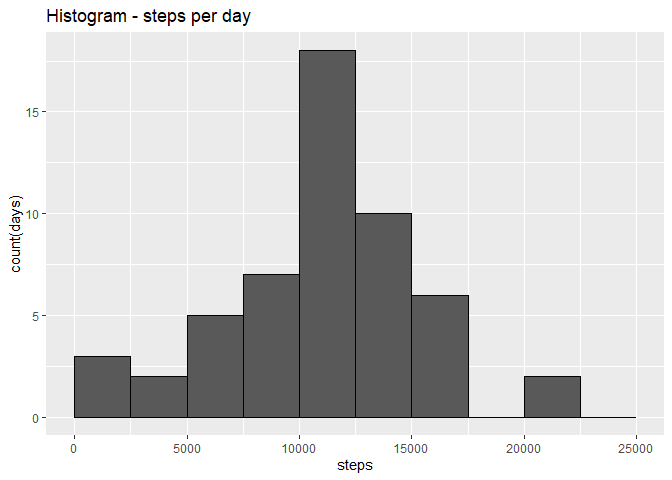

```r
g1 <- ggplot(tab1,aes(x=steps))+
geom_histogram(breaks=seq(0,25000,by=2500),col="black")+
ggtitle("Histogram - steps per day")+
ylab("count(days)")
print(g1)
```

3. Calculate and report the mean and median of the total number of steps taken per day

```r
m <- format(round(mean(tab1$steps)),big.mark=",")
md <- format(median(tab1$steps),big.mark=",")
```

Mean: **10,766** steps  
Median: **10,765** steps

## What is the average daily activity pattern?

1. Make a time series plot (i.e. type=“l”) of the 5-minute interval (x-axis) and the average number of steps taken, averaged across all days (y-axis)

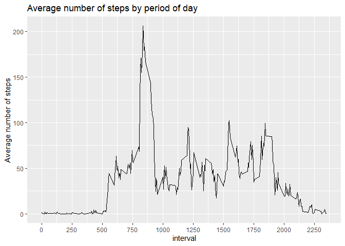

```r
mean_interval <- summarise(group_by(act_data,interval),mean=mean(steps,na.rm=T))
g2 <- ggplot(mean_interval,aes(x = interval,y = mean))+
geom_line()+
ggtitle("Average number of steps by period of day")+
ylab("Average number of steps")+xlab("interval")+
scale_x_continuous(breaks=seq(0,2355,by=250))
plot(g2)
```

2. Which 5-minute interval, on average across all the days in the dataset, contains the maximum number of steps?

```r
max_int <- mean_interval%>%filter(mean==max(mean))%>%pull(interval)
```

The interval that contains the maximum average is **835**